# Comparison performance of different models

In this notebook, we will train different models on a small part of the dataset in order to compare them and check which best suits for our problem. This notebook follows notebook `notebooks/data_processing/pab-analyze_full_db.ipynb` on data analysis.

# 1. Setup

In this section, we setup the notebook by :

- Import useful external libraries such that numpy, pandas, tensorflow, ...
- ⚠️⚠️⚠️ Manage Colab and tensorflow strategy : we will use Google Drive as storage when using colab, so becareful to change project folder path in your drive).
- Import personal modules (from `src` folder).
- Set default visualization for awesome graphics !
- Set default seed to replicate specific behavior implying random numbers.

```python
# Import base librairies
import sys
import os
import json
from pathlib import Path
import time

# Import scientific librairies
import pandas as pd
import numpy as np
import matplotlib.pyplot as plt
import seaborn as sns

# Import Tensorflow and Keras
import tensorflow as tf
from tensorflow import keras

# Import scikit-learn
from sklearn.utils import class_weight

# Check running environment
try:
    from google.colab import drive
    IN_COLAB=True
except:
    IN_COLAB=False

if IN_COLAB:
    print("We're running on Colab")

    # Install tensorflow-addons
    !pip install tensorflow_addons

    # Mount google drive
    mounting_point = "/content/drive/"
    drive.mount(mounting_point, force_remount=True)

    # Add project directory to kernel paths
    drive_folder = "MyDrive/Etudes/Epitech/MSc/MSc-1/Zoidberg_AI/T-DEV-810-PAR_10"
    sys.path.append(mounting_point + drive_folder)
else:
    print("We're running localy")

    # Add project directory to kernel paths
    sys.path.append('../..')
```

```
2023-05-22 00:35:43.858941: I tensorflow/core/platform/cpu_feature_guard.cc:193] This TensorFlow binary is optimized with oneAPI Deep Neural Network Library (oneDNN) to use the following CPU instructions in performance-critical operations:  SSE4.1 SSE4.2 AVX AVX2 FMA
To enable them in other operations, rebuild TensorFlow with the appropriate compiler flags.
```

```
We're running localy
```

```python
# Import custom functions
from src.visualization.plot_lib import default_viz
from src.data.file_manager import FileManager
from src.data.tf_utils import load_image_dataset_from_tfrecord, define_distribute_strategy
from src.data.evaluation import Evaluation

zoidbergManager = FileManager()
strategy = define_distribute_strategy()
evaluation = Evaluation(strategy)

# Set default graphics visualization
%matplotlib inline
default_viz()
```

```
Selected distribution strategy:                     _DefaultDistributionStrategy
```

```
2023-05-22 00:35:49.043140: I tensorflow/core/platform/cpu_feature_guard.cc:193] This TensorFlow binary is optimized with oneAPI Deep Neural Network Library (oneDNN) to use the following CPU instructions in performance-critical operations:  SSE4.1 SSE4.2 AVX AVX2 FMA
To enable them in other operations, rebuild TensorFlow with the appropriate compiler flags.
```

```python
# set random seed for keras, numpy, tensorflow, and the 'random' module
SEED = 42
tf.keras.utils.set_random_seed(SEED)
os.environ['PYTHONHASHSEED'] = str(SEED)
```

# 2. Loading dataset

First we define some variables :

- batch size : its value has been chosen as it is the highest one without reaching RAM upper bound.
- part of train / val set to use : as we will train several models, we don't want that is to computationally expensive thus we take only 20%.

```python
BATCH_SIZE = 64
SMALL_TRAIN_SPLIT = 0.2
SMALL_VAL_SPLIT = 0.2
class_names = ['bacteria', 'normal', 'virus']
```

Let's now load the train and val datasets :

```python
processed_dir_path = zoidbergManager.data_dir / 'processed'

train_path = str(processed_dir_path / 'train_512x512_rgb_ds.tfrecord')
val_path = str(processed_dir_path / 'val_512x512_rgb_ds.tfrecord')

train_ds = load_image_dataset_from_tfrecord(train_path)
val_ds = load_image_dataset_from_tfrecord(val_path)
```

Then, we extract the small part of each datasets and output number of images per class for each small datasets.

```python
num_train_img = train_ds.reduce(0, lambda x, _: x + 1).numpy()
num_val_img = val_ds.reduce(0, lambda x, _: x + 1).numpy()

# Shuffle data
train_ds = train_ds.shuffle(buffer_size=num_train_img, seed=42)
val_ds = val_ds.shuffle(buffer_size=num_val_img, seed=40)

# Extract a sample
small_train_size = int(num_train_img * SMALL_TRAIN_SPLIT)
small_val_size = int(num_val_img * SMALL_VAL_SPLIT)

small_train_ds = train_ds.take(small_train_size)
small_val_ds = val_ds.take(small_val_size)

def count_img_by_class(dataset, class_names=class_names):
    num_img_by_classes = {name:0 for name in class_names}
    for images, labels in dataset:
        idx_label = np.nonzero(labels.numpy())[0][0]
        for idx, name in enumerate(class_names):
            if idx_label == idx:
                num_img_by_classes[name] += 1
    return num_img_by_classes

print("In training dataset, there are :")
for class_name, num_img in count_img_by_class(small_train_ds).items():
    print(f"  - {num_img} files for class {class_name}")
print("\nIn val dataset, there are :")
for class_name, num_img in count_img_by_class(small_val_ds).items():
    print(f"  - {num_img} files for class {class_name}")
```

```
In training dataset, there are :
  - 504 files for class bacteria
  - 288 files for class normal
  - 262 files for class virus

In val dataset, there are :
  - 10 files for class bacteria
  - 9 files for class normal
  - 4 files for class virus
```

Finally, we also need to perform some actions on datasets before they can be used :

- batching images
- prefetching images : allows Tensorflow to preprocess and preload data in parallel of training i.e when batch $n$ is trained, batch $n+1$ is preloaded.

```python
# Batch & prefecth data to improve computation time
small_train_ds = small_train_ds.batch(BATCH_SIZE).prefetch(
    buffer_size=tf.data.AUTOTUNE)

small_val_ds = small_val_ds.batch(BATCH_SIZE).prefetch(
    buffer_size=tf.data.AUTOTUNE)
```

# 3. Compare a bunch of models

Let's now train models on this small dataset. We set useful variables below : number of epochs and learning rate.

⚠️⚠️⚠️ WARNING : Depending on your hardware, training cells can be computationally expensive and take a really long time to run them !!!  
That's why each of these cells are wrapped in a if condition (see `TRAIN_*MODEL*` booleans below).

```python
EPOCHS = 30
LEARNING_RATE = 0.0001

TRAIN_VGG16 = False
TRAIN_RESNET50 = False
TRAIN_INCEPTION_RESNET = False
TRAIN_XCEPTION = False
TRAIN_EFFICIENTNETB0 = False
```

We define also a callback :

- `checkpoint_cb` : save model at each epoch (only save best weight).

```python
def checkpoint_cb(model):
    checkpoint_dir = zoidbergManager.model_dir / 'checkpoints'
    checkpoint_filepath = checkpoint_dir / f'ckpt_smallds_{model.name}.h5'
    ckpt_cb = keras.callbacks.ModelCheckpoint(
        filepath=checkpoint_filepath,
        monitor='val_MCC',
        mode='max',
        save_best_only=True
    )
    return ckpt_cb
```

Next, we compute class weights to prevent imbalanced classes (as we saw when we analyzed data) :

```python
y_train_iterator = train_ds.map(lambda x, y: y).as_numpy_iterator()
y_train = []
for one_vector in y_train_iterator:
    y_train.append(one_vector)
y_train = np.argmax(y_train, axis=1)

class_weights = class_weight.compute_class_weight('balanced', classes=np.unique(y_train), y=y_train)

dic_class_weights = {}
for idx, weight in enumerate(class_weights):
    dic_class_weights[idx] = weight
    print(f'class {class_names[idx]} => weight : {weight:2f}')

class_weights_filepath = zoidbergManager.model_dir / 'class_weights.json'
json.dump(
    {'names': class_names,'weights': list(class_weights)},
    open(class_weights_filepath, 'w')
)
```

```
class bacteria => weight : 0.696393
class normal => weight : 1.241696
class virus => weight : 1.318080
```

Class weights are inverse proportionally to the number of inputs inside its class.

Finally, we define 2 functions to train a model and save its history :

```python
def save_history(model, history, training_time):
    dic = {}
    dic['history'] = history.history
    dic['training_time'] = training_time
    dic['epoch_time'] = training_time/len(history.history['loss'])
    history_dir = zoidbergManager.model_dir / 'histories'
    history_filepath = history_dir / f'hty_smallds_{model.name}.json'
    json.dump(dic, open(history_filepath, 'w'))

def train_model(model, save=False):
    start_time = time.time()
    history = model.fit(small_train_ds,
                        validation_data=small_val_ds,
                        epochs=EPOCHS,
                        #steps_per_epoch=(small_train_size // BATCH_SIZE + 1),
                        class_weight=dic_class_weights,
                        callbacks=[checkpoint_cb(model)],
                        )
    training_time = time.time() - start_time

    if save:
        save_history(model, history, training_time)

    return history, training_time
```

We selected 4 kinds of models to try. Those models have been chosen base on their performance :

- VGG and ResNet have been used several times on this dataset with some good performances. Many notebooks can be found on [kaggle](https://www.kaggle.com/datasets/paultimothymooney/chest-xray-pneumonia)
- Xception and EfficientNet have good results on imagenet with few parameters.

One can check performance of each model on imagenet here : [keras.applications](https://keras.io/api/applications/)

For each model :

1. We define the model on the function `make_*model*` where we set `trainable=False` for convolution layer. Model only learn on its top laye, like so one can check which base model performs best.
2. create an instance of the model with the defined Tensorflow strategy
3. Train the model and save its history

## 3.1 VGG

```python
def make_vgg16():
    base_vgg16 = tf.keras.applications.VGG16(weights='imagenet', input_shape=(224,224,3), include_top=False)
    for layer in base_vgg16.layers:
        layer.trainable = False

    vgg16 = tf.keras.Sequential([
        keras.layers.InputLayer(input_shape=(512,512,3), name='input'),
        keras.layers.Resizing(224, 224, interpolation="bilinear", name='resize'),
        keras.layers.Rescaling(scale=1./255., name='rescale'),
        base_vgg16,
        keras.layers.Flatten(name='flatten'),
        keras.layers.Dense(1024, activation='relu', name='fully_conn1'),
        keras.layers.Dense(512, activation='relu', name='fully_conn2'),
        keras.layers.Dense(3, activation='softmax', name='out_softmax'),
    ], name = 'vgg16')

    vgg16.compile(optimizer=keras.optimizers.Adam(learning_rate=LEARNING_RATE),
                  loss='categorical_crossentropy',
                  metrics=evaluation.get_training_metrics()
                 )
    return vgg16

with strategy.scope():
    vgg16 = make_vgg16()
```

```python
if TRAIN_VGG16:
    vgg16_history, vgg16_time = train_model(vgg16, save=True)
```

## 3.2 ResNet

### A. ResNet 50

```python
def make_resnet50():
    base_resnet50 = tf.keras.applications.ResNet50V2(weights='imagenet', input_shape=(224,224,3), include_top=False)
    for layer in base_resnet50.layers:
        layer.trainable = False

    resnet50 = tf.keras.Sequential([
        keras.layers.InputLayer(input_shape=(512,512,3), name='input'),
        keras.layers.Resizing(224, 224, interpolation="bilinear", name='resize'),
        keras.layers.Rescaling(scale=1./255., name='rescale'),
        base_resnet50,
        keras.layers.GlobalAveragePooling2D(name='avg_pool'),
        keras.layers.Dense(1024, activation='relu', name='fully_conn1'),
        keras.layers.Dense(512, activation='relu', name='fully_conn2'),
        keras.layers.Dense(3, activation='softmax', name='out_softmax'),
    ], name = 'resnet50')

    resnet50.compile(optimizer=keras.optimizers.Adam(learning_rate=LEARNING_RATE),
                  loss='categorical_crossentropy',
                  metrics=evaluation.get_training_metrics()
                 )
    return resnet50

with strategy.scope():
    resnet50 = make_resnet50()
```

```python
if TRAIN_RESNET50:
    resnet50_history, resnet50_time = train_model(resnet50, save=True)
```

### B. Inception-Resnet

```python
def make_inception_resnet():
    base_inception_resnet = tf.keras.applications.InceptionResNetV2(weights='imagenet', input_shape=(299,299,3), include_top=False)
    for layer in base_inception_resnet.layers:
        layer.trainable = False

    inception_resnet = tf.keras.Sequential([
        keras.layers.InputLayer(input_shape=(512,512,3), name='input'),
        keras.layers.Resizing(299, 299, interpolation="bilinear", name='resize'),
        keras.layers.Rescaling(scale=1./255., name='rescale'),
        base_inception_resnet,
        keras.layers.GlobalAveragePooling2D(name='avg_pool'),
        keras.layers.Dense(1024, activation='relu', name='fully_conn1'),
        keras.layers.Dense(512, activation='relu', name='fully_conn2'),
        keras.layers.Dense(3, activation='softmax', name='out_softmax'),
    ], name = 'inception_resnet')

    inception_resnet.compile(optimizer=keras.optimizers.Adam(learning_rate=LEARNING_RATE),
                  loss='categorical_crossentropy',
                  metrics=evaluation.get_training_metrics()
                 )
    return inception_resnet

with strategy.scope():
    inception_resnet = make_inception_resnet()
```

```python
if TRAIN_INCEPTION_RESNET:
    inception_resnet_history, inception_resnet_time = train_model(inception_resnet, save=True)
```

## 3.3 Xception

```python
def make_xception():
    base_xception = tf.keras.applications.Xception(weights='imagenet', input_shape=(299,299,3), include_top=False)
    for layer in base_xception.layers:
        layer.trainable = False

    xception = tf.keras.Sequential([
        keras.layers.InputLayer(input_shape=(512,512,3), name='input'),
        keras.layers.Resizing(299, 299, interpolation="bilinear", name='resize'),
        keras.layers.Rescaling(scale=1./255., name='rescale'),
        base_xception,
        keras.layers.GlobalAveragePooling2D(name='avg_pool'),
        keras.layers.Dense(1024, activation='relu', name='fully_conn1'),
        keras.layers.Dense(512, activation='relu', name='fully_conn2'),
        keras.layers.Dense(3, activation='softmax', name='out_softmax'),
    ], name = 'xception')

    xception.compile(optimizer=keras.optimizers.Adam(learning_rate=LEARNING_RATE),
                  loss='categorical_crossentropy',
                  metrics=evaluation.get_training_metrics()
                 )
    return xception

with strategy.scope():
    xception = make_xception()
```

```python
if TRAIN_XCEPTION:
    xception_history, xception_time = train_model(xception, save=True)
```

## 3.4 EfficientNet

```python
def make_efficientnetb0():
    base_efficientnetb0 = tf.keras.applications.EfficientNetV2B0(weights='imagenet', input_shape=(224,224,3), include_top=False)
    for layer in base_efficientnetb0.layers:
        layer.trainable = False

    efficientnetb0 = tf.keras.Sequential([
        keras.layers.InputLayer(input_shape=(512,512,3), name='input'),
        keras.layers.Resizing(224, 224, interpolation="bilinear", name='resize'),
        base_efficientnetb0,
        keras.layers.GlobalAveragePooling2D(name='avg_pool'),
        keras.layers.Dense(1024, activation='relu', name='fully_conn1'),
        keras.layers.Dense(512, activation='relu', name='fully_conn2'),
        keras.layers.Dense(3, activation='softmax', name='out_softmax'),
    ], name = 'efficientnetb0')

    efficientnetb0.compile(optimizer=keras.optimizers.Adam(learning_rate=LEARNING_RATE),
                  loss='categorical_crossentropy',
                  metrics=evaluation.get_training_metrics()
                 )
    return efficientnetb0

with strategy.scope():
    efficientnetb0 = make_efficientnetb0()
```

```python
if TRAIN_EFFICIENTNETB0:
    efficientnetb0_history, efficientnetb0_time = train_model(efficientnetb0, save=True)
```

## 3.5 Results

Finally, let's check results of each models !

We load each history and sum up results :

```python
history_path = {
    'vgg16' : zoidbergManager.model_dir / 'histories' / 'hty_smallds_vgg16.json',
    'resnet50' : zoidbergManager.model_dir / 'histories' / 'hty_smallds_resnet50.json',
    'inception_resnet' : zoidbergManager.model_dir / 'histories' / 'hty_smallds_inception_resnet.json',
    'xception' : zoidbergManager.model_dir / 'histories' / 'hty_smallds_xception.json',
    'efficientnetb0' : zoidbergManager.model_dir / 'histories' / 'hty_smallds_efficientnetb0.json'
}

checkpoint_path = {
    'vgg16' : zoidbergManager.model_dir / 'checkpoints' / 'ckpt_smallds_vgg16.h5',
    'resnet50' : zoidbergManager.model_dir / 'checkpoints' / 'ckpt_smallds_resnet50.h5',
    'inception_resnet' : zoidbergManager.model_dir / 'checkpoints' / 'ckpt_smallds_inception_resnet.h5',
    'xception' : zoidbergManager.model_dir / 'checkpoints' / 'ckpt_smallds_xception.h5',
    'efficientnetb0' : zoidbergManager.model_dir / 'checkpoints' / 'ckpt_smallds_efficientnetb0.h5'
}

sumup_result_df = pd.DataFrame(columns=['model','size','training_time','max MCC','max val_MCC'])
histories = {}
for model_name, path in history_path.items():
    with open(path) as file:
        history = json.load(file)
    histories[model_name] = history['history']
    sumup = []
    sumup.append(model_name)
    sumup.append(f'{checkpoint_path[model_name].stat().st_size / (1e6):.1f} MB')
    sumup.append(f"{history['training_time']:.3f} s")
    sumup.append(f"{np.max(history['history']['MCC']):.3f}")
    sumup.append(f"{np.max(history['history']['val_MCC']):.3f}")
    idx_model = list(history_path.keys()).index(model_name)
    sumup_result_df.loc[idx_model] = sumup

sumup_result_df.head()
```

|  | model | size | training_time | max MCC | max val_MCC |
| --- | --- | --- | --- | --- | --- |
| 0 | vgg16 | 373.5 MB | 134.558 s | 0.813 | 0.936 |
| 1 | resnet50 | 126.1 MB | 116.171 s | 0.846 | 0.932 |
| 2 | inception_resnet | 243.8 MB | 160.091 s | 0.688 | 0.863 |
| 3 | xception | 115.2 MB | 128.389 s | 0.775 | 0.929 |
| 4 | efficientnetb0 | 46.2 MB | 118.896 s | 0.751 | 1.000 |

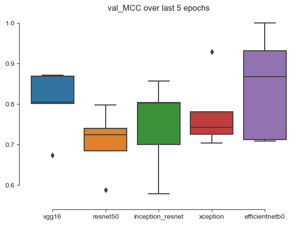

```python
mcc_history = {}
for model, history in histories.items():
    mcc_history[model] = history['val_MCC']

sns.set_style('ticks')
bp = sns.boxplot(data=pd.DataFrame.from_dict(mcc_history).iloc[-5:])
bp.set_title('val_MCC over last 5 epochs')
sns.despine(offset=10, trim=True)

plt.savefig(zoidbergManager.resource_dir / 'models_comparison.png')
```

After examining the Matthew coefficient on the validation set, it becomes evident that ResNet, Xception, and Inception-ResNet exhibit lower performance compared to VGG or EfficientNet.

Considering the trade-off between performance and computational efficiency, our choice aligns with EfficientNet as the preferred model. Its ability to deliver strong results while being more manageable in terms of model size and training time makes it a compelling option for our specific needs.

To confirm this decision, let's just check learning curve of each model :

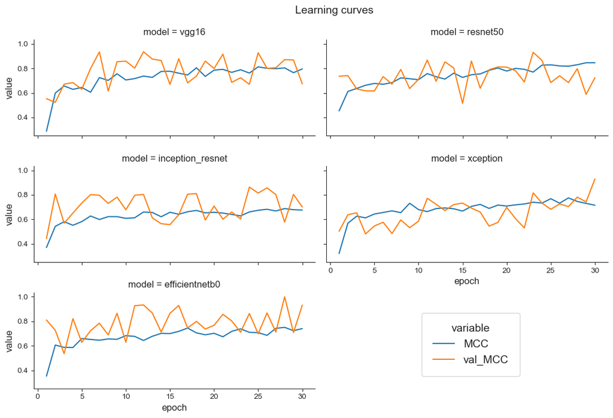

```python
epochs = list(range(1,EPOCHS+1))
full_mcc_history = []
for model, history in histories.items():
    data = {}
    data['epoch'] = epochs
    data['model'] = [model]*EPOCHS
    data['MCC'] = history['MCC']
    data['val_MCC'] = history['val_MCC']
    full_mcc_history.append(pd.DataFrame.from_dict(data))
full_mcc_history_df = pd.concat(full_mcc_history)

sns.set_style('ticks')
rp = sns.relplot(
    data=pd.melt(full_mcc_history_df,['epoch','model']),
    x="epoch",
    y="value",
    hue="variable",
    col="model",
    col_wrap=2,
    height=2.5,
    aspect=2.2,
    kind="line"
)
rp.fig.suptitle('Learning curves', fontsize=14)
rp.fig.subplots_adjust(top=0.9)
sns.move_legend(rp,
                'center',
                bbox_to_anchor=(.7, .18),
                fontsize=14,
                title_fontsize=14,
                frameon=True,
                borderpad=1)

plt.savefig(zoidbergManager.resource_dir / 'models_learning_curves.png')
```

Upon analyzing the learning curves of the different models, it becomes evident that none of them exhibit a pronounced case of overfitting. This observation is encouraging, as it suggests that the models are not excessively fitting the training data at the expense of generalization.

Based on this finding, we reaffirm our initial choice of utilizing **EfficientNet B0**.